# Ontology_forpub

Anonymized

2025-07-30

# Participant Demographics

```
ont_ctry_name
Ecuador   Ghana    Peru      US
     20      70      40      49
             ont_version
ont_ctry_name  1  2
      Ecuador 10 10
      Ghana   35 35
      Peru    21 19
      US      21 28
```

| ont_ctry_name | n | mean_age | med_age | sd_age | range_age |
| --- | --- | --- | --- | --- | --- |
| Ecuador | 20 | 27.50000 | 25.0 | 8.654175 | 18 - 50 |
| Ghana | 70 | 33.01429 | 27.5 | 13.261574 | 18 - 67 |
| Peru | 40 | 39.87500 | 37.5 | 13.305460 | 19 - 72 |
| US | 49 | 42.21277 | 35.0 | 16.268048 | 19 - 79 |

```
             ont_sex
ont_ctry_name  .  1  2
      Ecuador  0  9 11
      Ghana    0 32 38
      Peru     0 25 15
      US       1 26 22
                                                      ont_ctry_name
tolower(ont_ethn)                                      Ecuador Ghana Peru US
  .                                                          0     1    0  2
  a little bit of everything / caucasian/ puerto rican       0     0    0  1
  ahanta                                                     0     1    0  0
  akan- fante                                                0     1    0  0
  american - hispanic / anglo                                0     0    0  1
  asante/akan                                                0     1    0  0
  asian                                                      0     0    0  1
  asian + caucasian                                          0     0    0  1
  black                                                      0     0    0  2
  black + puerto rican                                       0     0    0  1
  caucasian                                                  0     0    0 22
  denkyiranyi (asante)                                       0     1    0  0
  earth inn                                                  0     0    0  1
  east indian                                                0     0    0  1
  ekuapim                                                    0     1    0  0
  fante                                                      0    49    0  0
  fante (akromah)                                            0     1    0  0
  fante (amosima)                                            0     1    0  0
  fante (brenu)                                              0     1    0  0
  fante (new ebu)                                            0     2    0  0
  fante (otum in central region)                             0     1    0  0
  fantenyi                                                   0     2    0  0
  fanti                                                      0     1    0  0
  fanti (cape-coast)                                         0     1    0  0
  fanti (egyankwa)                                           0     1    0  0
  fanti (yamoransa)                                          0     1    0  0
  fanti(ahanta)                                              0     1    0  0
  hispanic                                                   0     0    0  1
  hispanic / caucasian                                       0     0    0  1
  hispanic / native american                                 0     0    0  1
  i am a fante.                                              0     1    0  0
  irish                                                      0     0    0  1
```

[output cut: 179 more lines]

```
  when i am in school, i go to church every day                           0     1    0  0
  yes, once a month                                                       0     0    1  0
  you don't go at all.                                                    0     1    0  0
             as.numeric(ont_ses)
ont_ctry_name -2 -1  0  1  2
      Ecuador  0 10  9  1  0
      Ghana    4 17 15 31  3
      Peru    13  6 18  1  0
      US       2 13 23  8  1
             as.numeric(ont_affr)
ont_ctry_name  0  1
      Ecuador 20  0
      Ghana   23 47
      Peru    30  9
      US       5 43
```

# Figure 1, Accompanying Analyses & Appendix C regression results

This way, a person who said they don’t know if it exists and a person who said it did or didn’t but said they were “not sure” will both get a score of 0. A person who is “very sure” it doesn’t exist will get a score of -3 and a person who is “very sure” it does exist will get a score of 3.

Graphing Figure 1

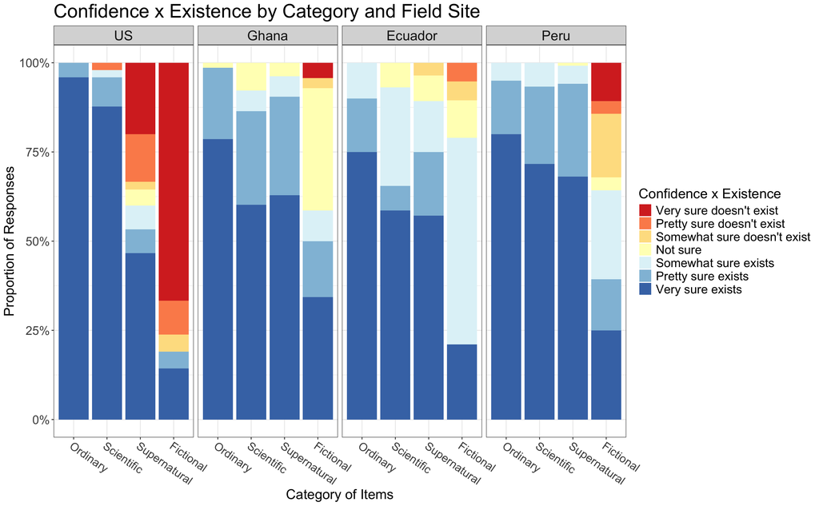

Models predicting confidence x existence scores by category with separate regressions for each country. The pairwise contrasts here showing ordinary vs. supernatural and scientific vs. supernatural are what make up Table 2. Full results are reported in Appendix C.

```
Linear mixed model fit by REML. t-tests use Satterthwaite's method ['lmerModLmerTest']
Formula: conf_dir ~ question_type + (1 | ont_subj)
   Data: filter(df_ext_usens_conf, ont_ctry_name == "US")

REML criterion at convergence: 623.3

Scaled residuals:
     Min       1Q   Median       3Q      Max
-2.90811 -0.26981  0.03141  0.27885  2.87739

Random effects:
 Groups   Name        Variance Std.Dev.
 ont_subj (Intercept) 0.2108   0.4591
 Residual             2.4359   1.5607
Number of obs: 164, groups:  ont_subj, 49

Fixed effects:
                          Estimate Std. Error       df t value Pr(>|t|)
(Intercept)                 2.9592     0.2324 157.8701  12.733  < 2e-16 ***
question_typeScientific    -0.1837     0.3153 117.5352  -0.583    0.561
question_typeSupernatural  -2.2480     0.3228 120.0307  -6.965 1.89e-10 ***
question_typeFictional     -4.5905     0.4127 137.1724 -11.124  < 2e-16 ***
---
Signif. codes:  0 ‘***’ 0.001 ‘**’ 0.01 ‘*’ 0.05 ‘.’ 0.1 ‘ ’ 1

Correlation of Fixed Effects:
            (Intr) qstn_typSc qstn_typSp
qstn_typScn -0.678
qstn_typSpr -0.663  0.488
qstn_typFct -0.518  0.382      0.376
 contrast                  estimate    SE  df t.ratio p.value
 Ordinary - Scientific        0.184 0.315 113   0.583  0.5614
 Ordinary - Supernatural      2.248 0.323 116   6.962  <.0001
 Ordinary - Fictional         4.590 0.415 134  11.069  <.0001
 Scientific - Supernatural    2.064 0.323 116   6.393  <.0001
 Scientific - Fictional       4.407 0.415 134  10.626  <.0001
 Supernatural - Fictional     2.343 0.420 132   5.584  <.0001

Degrees-of-freedom method: kenward-roger
Linear mixed model fit by REML. t-tests use Satterthwaite's method ['lmerModLmerTest']
```

[output cut: 101 more lines]

```

Correlation of Fixed Effects:
            (Intr) qstn_typSc qstn_typSp
qstn_typScn -0.754
qstn_typSpr -0.843  0.669
qstn_typFct -0.623  0.497      0.553
 contrast                  estimate    SE  df t.ratio p.value
 Ordinary - Scientific       0.1076 0.175 208   0.615  0.5393
 Ordinary - Supernatural     0.1367 0.156 205   0.874  0.3830
 Ordinary - Fictional        2.0389 0.212 213   9.627  <.0001
 Scientific - Supernatural   0.0291 0.136 210   0.214  0.8305
 Scientific - Fictional      1.9313 0.197 213   9.821  <.0001
 Supernatural - Fictional    1.9022 0.181 217  10.516  <.0001

Degrees-of-freedom method: kenward-roger
```

Model predicting confidence x existence scores by category pooling across non-US countries. These results show that when you combine all non-US country responses together, the difference between ordinary and supernatural confidence ratings are significant.

```
Linear mixed model fit by REML. t-tests use Satterthwaite's method ['lmerModLmerTest']
Formula: conf_dir ~ question_type + (1 | ont_ctry_name/ont_subj)
   Data: filter(df_ext_usens_conf, ont_ctry_name != "US")

REML criterion at convergence: 1924

Scaled residuals:
    Min      1Q  Median      3Q     Max
-4.3864 -0.4471  0.2510  0.5377  2.2025

Random effects:
 Groups                 Name        Variance Std.Dev.
 ont_subj:ont_ctry_name (Intercept) 0.113627 0.33709
 ont_ctry_name          (Intercept) 0.003539 0.05949
 Residual                           0.844475 0.91895
Number of obs: 691, groups:  ont_subj:ont_ctry_name, 130; ont_ctry_name, 3

Fixed effects:
                           Estimate Std. Error        df t value Pr(>|t|)
(Intercept)                 2.72942    0.09344   3.60849  29.210 2.03e-05 ***
question_typeScientific    -0.29739    0.10470 563.96137  -2.840  0.00467 **
question_typeSupernatural  -0.23851    0.09985 550.18991  -2.389  0.01724 *
question_typeFictional     -1.63053    0.11738 560.02347 -13.891  < 2e-16 ***
---
Signif. codes:  0 ‘***’ 0.001 ‘**’ 0.01 ‘*’ 0.05 ‘.’ 0.1 ‘ ’ 1

Correlation of Fixed Effects:
            (Intr) qstn_typSc qstn_typSp
qstn_typScn -0.664
qstn_typSpr -0.698  0.618
qstn_typFct -0.591  0.529      0.551
 contrast                  estimate     SE  df t.ratio p.value
 Ordinary - Scientific       0.2974 0.1050 569   2.840  0.0047
 Ordinary - Supernatural     0.2385 0.1010 564   2.373  0.0180
 Ordinary - Fictional        1.6305 0.1180 565  13.874  <.0001
 Scientific - Supernatural  -0.0589 0.0903 590  -0.652  0.5144
 Scientific - Fictional      1.3331 0.1080 573  12.292  <.0001
 Supernatural - Fictional    1.3920 0.1060 561  13.190  <.0001

Degrees-of-freedom method: kenward-roger
```

Model predicting confidence x existence scores by category, but only for highest contrast ordinary vs. supernatural items (coffee cups & tables vs. God & demons). These results show that these highest contrasts are significantly different in the US and Ghana, but not in Ecuador and Peru (in Ecuador, our smallest sample size, there are hints that this effect might be found in future similar studies). See Appendix A for full confidence and existence ratings broken down by item, version, and country.

```
Linear mixed model fit by REML. t-tests use Satterthwaite's method ['lmerModLmerTest']
Formula: conf_dir ~ question_type + (1 | ont_subj)
   Data: df_ext_usens_conf %>% filter(ont_ctry_name == "US", item_code %in%
    c("mug", "tbl", "dem", "god"))

REML criterion at convergence: 374.1

Scaled residuals:
     Min       1Q   Median       3Q      Max
-2.09043  0.01938  0.02299  0.58511  1.29077

Random effects:
 Groups   Name        Variance Std.Dev.
 ont_subj (Intercept) 0.008797 0.09379
 Residual             3.134276 1.77039
Number of obs: 94, groups:  ont_subj, 49

Fixed effects:
                          Estimate Std. Error      df t value Pr(>|t|)
(Intercept)                 2.9592     0.2533 91.9994   11.68  < 2e-16 ***
question_typeSupernatural  -2.2481     0.3656 48.9678   -6.15 1.38e-07 ***
---
Signif. codes:  0 ‘***’ 0.001 ‘**’ 0.01 ‘*’ 0.05 ‘.’ 0.1 ‘ ’ 1

Correlation of Fixed Effects:
            (Intr)
qstn_typSpr -0.691
Linear mixed model fit by REML. t-tests use Satterthwaite's method ['lmerModLmerTest']
Formula: conf_dir ~ question_type + (1 | ont_subj)
   Data: df_ext_usens_conf %>% filter(ont_ctry_name == "Ghana", item_code %in%
    c("mug", "tbl", "dem", "god"))

REML criterion at convergence: 291.4

Scaled residuals:
    Min      1Q  Median      3Q     Max
-3.3442 -0.1527 -0.0012  0.5653  1.7544

Random effects:
 Groups   Name        Variance Std.Dev.
```

[output cut: 53 more lines]

```
 Groups   Name        Variance Std.Dev.
 ont_subj (Intercept) 0.01877  0.1370
 Residual             0.25314  0.5031
Number of obs: 79, groups:  ont_subj, 40

Fixed effects:
                           Estimate Std. Error        df t value Pr(>|t|)
(Intercept)                2.750000   0.082449 76.628610  33.354   <2e-16 ***
question_typeSupernatural -0.007738   0.113272 38.128326  -0.068    0.946
---
Signif. codes:  0 ‘***’ 0.001 ‘**’ 0.01 ‘*’ 0.05 ‘.’ 0.1 ‘ ’ 1

Correlation of Fixed Effects:
            (Intr)
qstn_typSpr -0.678
```

# Figure 2 & Accompanying Analyses

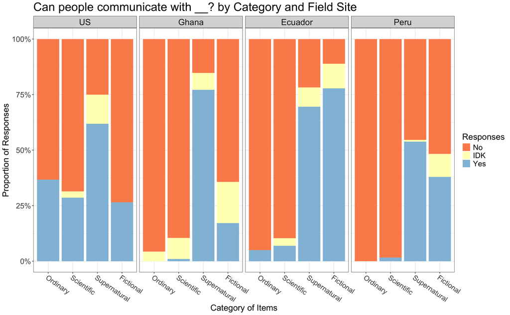

Models predicting “Can people communicate with X?” responses by category. The pairwise contrasts from these models are reported in the manuscript under the section “Additional Questions Reflect Differences in Epistemic Frames”

```
Linear mixed model fit by REML. t-tests use Satterthwaite's method ['lmerModLmerTest']
Formula: response ~ category + (1 | ont_subj)
   Data: filter(data_long_comm, ont_ctry_name == "US")

REML criterion at convergence: 262

Scaled residuals:
    Min      1Q  Median      3Q     Max
-1.9138 -0.6348 -0.1107  0.6635  2.5365

Random effects:
 Groups   Name        Variance Std.Dev.
 ont_subj (Intercept) 0.08442  0.2905
 Residual             0.12076  0.3475
Number of obs: 244, groups:  ont_subj, 49

Fixed effects:
                      Estimate Std. Error        df t value Pr(>|t|)
(Intercept)            0.36735    0.06471 142.69707   5.677  7.4e-08 ***
categoryScientific    -0.03998    0.06510 193.23170  -0.614    0.540
categoryFictional     -0.10204    0.07021 191.90328  -1.453    0.148
categorySupernatural   0.28896    0.06399 193.08577   4.515  1.1e-05 ***
---
Signif. codes:  0 ‘***’ 0.001 ‘**’ 0.01 ‘*’ 0.05 ‘.’ 0.1 ‘ ’ 1

Correlation of Fixed Effects:
            (Intr) ctgrySc ctgryF
ctgryScntfc -0.585
catgryFctnl -0.542  0.539
ctgrySprntr -0.595  0.581   0.549
 contrast                  estimate     SE  df t.ratio p.value
 Ordinary - Scientific       0.0400 0.0651 193   0.614  0.5399
 Ordinary - Fictional        0.1020 0.0702 192   1.453  0.1477
 Ordinary - Supernatural    -0.2890 0.0640 193  -4.515  <.0001
 Scientific - Fictional      0.0621 0.0651 193   0.953  0.3417
 Scientific - Supernatural  -0.3289 0.0591 198  -5.564  <.0001
 Fictional - Supernatural   -0.3910 0.0640 193  -6.109  <.0001

Degrees-of-freedom method: kenward-roger
Linear mixed model fit by REML. t-tests use Satterthwaite's method ['lmerModLmerTest']
```

[output cut: 101 more lines]

```

Correlation of Fixed Effects:
            (Intr) ctgrySc ctgryF
ctgryScntfc -0.766
catgryFctnl -0.641  0.502
ctgrySprntr -0.856  0.670   0.560
 contrast                  estimate     SE  df t.ratio p.value
 Ordinary - Scientific       -0.016 0.0784 209  -0.204  0.8384
 Ordinary - Fictional        -0.428 0.0938 215  -4.560  <.0001
 Ordinary - Supernatural     -0.542 0.0701 206  -7.731  <.0001
 Scientific - Fictional      -0.412 0.0870 215  -4.733  <.0001
 Scientific - Supernatural   -0.526 0.0608 212  -8.644  <.0001
 Fictional - Supernatural    -0.114 0.0797 218  -1.433  0.1533

Degrees-of-freedom method: kenward-roger
```

# Figure 3 & Accompanying Analyses

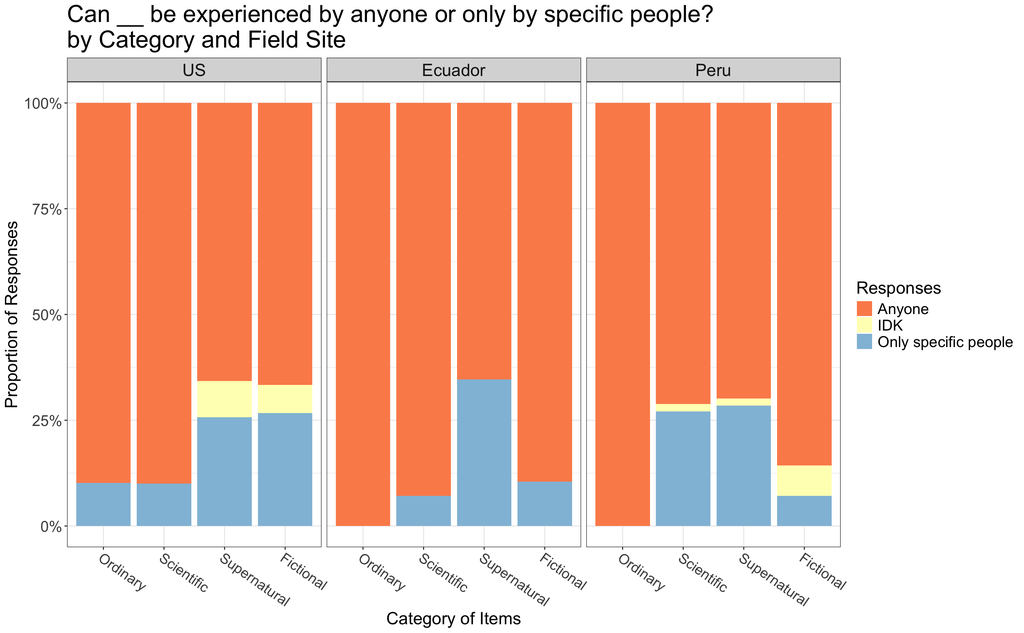

Models predicting “Can X be experienced by anyone or only by specific people?” responses by category. The pairwise contrasts from these models are reported in the manuscript under the section “Additional Questions Reflect Differences in Epistemic Frames”

```
Linear mixed model fit by REML. t-tests use Satterthwaite's method ['lmerModLmerTest']
Formula: response ~ category + (1 | ont_subj)
   Data: filter(data_long_spec, ont_ctry_name == "US")

REML criterion at convergence: 220.1

Scaled residuals:
    Min      1Q  Median      3Q     Max
-0.9216 -0.7635 -0.2711 -0.2271  2.4120

Random effects:
 Groups   Name        Variance Std.Dev.
 ont_subj (Intercept) 0.002358 0.04856
 Residual             0.139782 0.37387
Number of obs: 234, groups:  ont_subj, 49

Fixed effects:
                       Estimate Std. Error         df t value Pr(>|t|)
(Intercept)            0.102041   0.053859 229.724066   1.895  0.05940 .
categoryScientific    -0.002248   0.069678 189.097447  -0.032  0.97429
categoryFictional      0.197425   0.077221 187.294488   2.557  0.01136 *
categorySupernatural   0.197507   0.069704 192.401201   2.834  0.00509 **
---
Signif. codes:  0 ‘***’ 0.001 ‘**’ 0.01 ‘*’ 0.05 ‘.’ 0.1 ‘ ’ 1

Correlation of Fixed Effects:
            (Intr) ctgrySc ctgryF
ctgryScntfc -0.760
catgryFctnl -0.686  0.530
ctgrySprntr -0.760  0.586   0.531
 contrast                   estimate     SE  df t.ratio p.value
 Ordinary - Scientific      2.25e-03 0.0697 188   0.032  0.9743
 Ordinary - Fictional      -1.97e-01 0.0772 186  -2.556  0.0114
 Ordinary - Supernatural   -1.98e-01 0.0698 191  -2.831  0.0051
 Scientific - Fictional    -2.00e-01 0.0716 194  -2.788  0.0058
 Scientific - Supernatural -2.00e-01 0.0636 210  -3.139  0.0019
 Fictional - Supernatural  -8.18e-05 0.0715 188  -0.001  0.9991

Degrees-of-freedom method: kenward-roger
Linear mixed model fit by REML. t-tests use Satterthwaite's method ['lmerModLmerTest']
```

[output cut: 62 more lines]

```

Correlation of Fixed Effects:
            (Intr) ctgrySc ctgryF
ctgryScntfc -0.767
catgryFctnl -0.637  0.495
ctgrySprntr -0.857  0.665   0.553
 contrast                  estimate     SE  df t.ratio p.value
 Ordinary - Scientific      -0.2796 0.0806 206  -3.469  0.0006
 Ordinary - Fictional       -0.1064 0.0971 211  -1.096  0.2743
 Ordinary - Supernatural    -0.2931 0.0721 201  -4.066  0.0001
 Scientific - Fictional      0.1732 0.0904 212   1.915  0.0568
 Scientific - Supernatural  -0.0135 0.0629 208  -0.214  0.8304
 Fictional - Supernatural   -0.1867 0.0830 215  -2.248  0.0256

Degrees-of-freedom method: kenward-roger
```

# Figure 4

Can __ be sensed? This combines across all sensory questions for each item. The items differed from country to country and version to version. But almost all contain the questions: see, hear, smell, touch, feel. Many but not all also had a taste question.

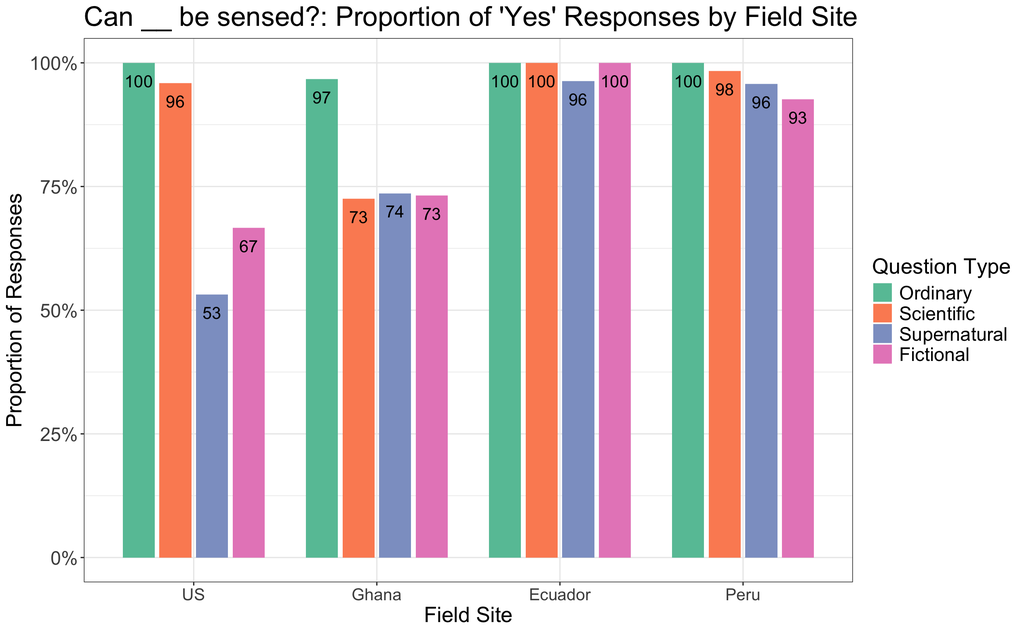

# Figure 5

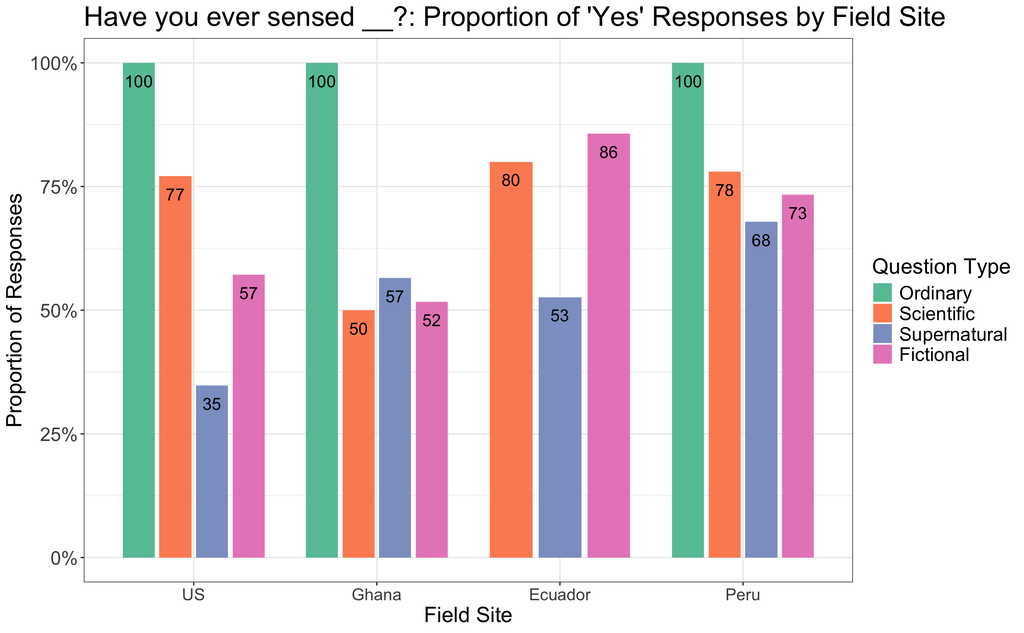

# Table 3 & Accompanying Analyses

Models predicting confidence x existence scores with consensus and sensory experience scores. The results are reported in Table 3 in the manuscript

```
Linear mixed model fit by REML. t-tests use Satterthwaite's method ['lmerModLmerTest']
Formula: conf_dir ~ consensus_excl_self + usens_response + (1 | ont_ctry_name/ont_subj)
   Data: df_ext_usens_conf

REML criterion at convergence: 2134.2

Scaled residuals:
    Min      1Q  Median      3Q     Max
-4.2610 -0.4330  0.0861  0.3859  3.9757

Random effects:
 Groups                 Name        Variance Std.Dev.
 ont_subj:ont_ctry_name (Intercept) 0.132745 0.36434
 ont_ctry_name          (Intercept) 0.009728 0.09863
 Residual                           1.040922 1.02026
Number of obs: 714, groups:  ont_subj:ont_ctry_name, 177; ont_ctry_name, 4

Fixed effects:
                     Estimate Std. Error        df t value Pr(>|t|)
(Intercept)          -2.92816    0.21417  76.07243 -13.672   <2e-16 ***
consensus_excl_self   5.00615    0.22733 354.91570  22.022   <2e-16 ***
usens_response        0.78817    0.09002 688.50272   8.756   <2e-16 ***
---
Signif. codes:  0 ‘***’ 0.001 ‘**’ 0.01 ‘*’ 0.05 ‘.’ 0.1 ‘ ’ 1

Correlation of Fixed Effects:
            (Intr) cnsn__
cnsnss_xcl_ -0.900
usens_rspns -0.099 -0.197
```

Regression Results: Effects of Consensus and Sensory Evidence on Confidence

| **Characteristic** | **Beta** | **95% CI** | **p-value** |
| --- | --- | --- | --- |
| (Intercept) | -2.9 | -3.4, -2.5 | <0.001 |
| consensus_excl_self | 5.0 | 4.6, 5.5 | <0.001 |
| usens_response | 0.79 | 0.61, 0.96 | <0.001 |

Abbreviation: CI = Confidence Interval

# ALTERNATE CODING & FIG 1 et al

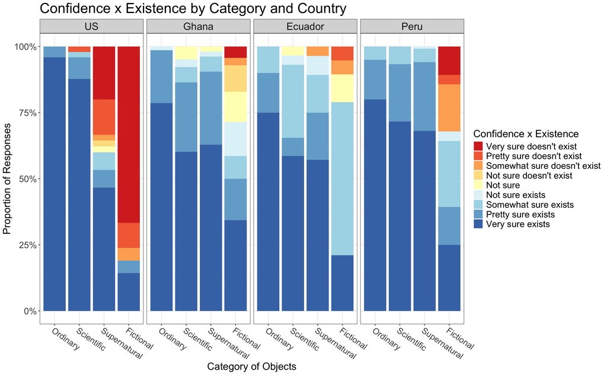

```
Linear mixed model fit by REML. t-tests use Satterthwaite's method ['lmerModLmerTest']
Formula: conf_dir ~ question_type + (1 | ont_subj)
   Data: filter(df_ext_usens_conf_ALT, ont_ctry_name == "US")

REML criterion at convergence: 735.9

Scaled residuals:
     Min       1Q   Median       3Q      Max
-3.05877 -0.27588  0.01684  0.27397  2.88053

Random effects:
 Groups   Name        Variance Std.Dev.
 ont_subj (Intercept) 0.3683   0.6069
 Residual             4.4209   2.1026
Number of obs: 168, groups:  ont_subj, 49

Fixed effects:
                          Estimate Std. Error       df t value Pr(>|t|)
(Intercept)                 3.9592     0.3126 161.8633  12.664  < 2e-16 ***
question_typeScientific    -0.2245     0.4248 120.1173  -0.528    0.598
question_typeSupernatural  -3.1020     0.4248 120.1173  -7.303 3.37e-11 ***
question_typeFictional     -6.1828     0.5557 140.3890 -11.127  < 2e-16 ***
---
Signif. codes:  0 ‘***’ 0.001 ‘**’ 0.01 ‘*’ 0.05 ‘.’ 0.1 ‘ ’ 1

Correlation of Fixed Effects:
            (Intr) qstn_typSc qstn_typSp
qstn_typScn -0.679
qstn_typSpr -0.679  0.500
qstn_typFct -0.519  0.382      0.382
 contrast                  estimate    SE  df t.ratio p.value
 Ordinary - Scientific        0.224 0.425 117   0.528  0.5982
 Ordinary - Supernatural      3.102 0.425 117   7.303  <.0001
 Ordinary - Fictional         6.183 0.558 138  11.072  <.0001
 Scientific - Supernatural    2.878 0.425 117   6.774  <.0001
 Scientific - Fictional       5.958 0.558 138  10.670  <.0001
 Supernatural - Fictional     3.081 0.558 138   5.517  <.0001

Degrees-of-freedom method: kenward-roger
Linear mixed model fit by REML. t-tests use Satterthwaite's method ['lmerModLmerTest']
```

[output cut: 101 more lines]

```

Correlation of Fixed Effects:
            (Intr) qstn_typSc qstn_typSp
qstn_typScn -0.762
qstn_typSpr -0.850  0.672
qstn_typFct -0.653  0.518      0.576
 contrast                  estimate    SE  df t.ratio p.value
 Ordinary - Scientific      0.16633 0.231 214   0.721  0.4719
 Ordinary - Supernatural    0.16667 0.207 210   0.806  0.4212
 Ordinary - Fictional       2.81673 0.269 217  10.459  <.0001
 Scientific - Supernatural  0.00034 0.179 216   0.002  0.9985
 Scientific - Fictional     2.65040 0.248 217  10.692  <.0001
 Supernatural - Fictional   2.65006 0.226 219  11.718  <.0001

Degrees-of-freedom method: kenward-roger
```

Model predicting confidence x existence scores by category pooling across non-US countries. These results show that when you combine all non-US country responses together, the difference between ordinary and supernatural confidence ratings are significant.

```
Linear mixed model fit by REML. t-tests use Satterthwaite's method ['lmerModLmerTest']
Formula: conf_dir ~ question_type + (1 | ont_ctry_name/ont_subj)
   Data: filter(df_ext_usens_conf_ALT, ont_ctry_name != "US")

REML criterion at convergence: 2293.9

Scaled residuals:
    Min      1Q  Median      3Q     Max
-4.5239 -0.3322  0.2444  0.4483  2.0520

Random effects:
 Groups                 Name        Variance Std.Dev.
 ont_subj:ont_ctry_name (Intercept) 0.1228   0.3504
 ont_ctry_name          (Intercept) 0.0000   0.0000
 Residual                           1.4453   1.2022
Number of obs: 698, groups:  ont_subj:ont_ctry_name, 130; ont_ctry_name, 3

Fixed effects:
                          Estimate Std. Error       df t value Pr(>|t|)
(Intercept)                 3.7385     0.1098 674.2405  34.039  < 2e-16 ***
question_typeScientific    -0.3647     0.1366 571.9140  -2.671  0.00779 **
question_typeSupernatural  -0.2598     0.1302 578.2497  -1.996  0.04639 *
question_typeFictional     -2.1671     0.1520 566.5738 -14.255  < 2e-16 ***
---
Signif. codes:  0 ‘***’ 0.001 ‘**’ 0.01 ‘*’ 0.05 ‘.’ 0.1 ‘ ’ 1

Correlation of Fixed Effects:
            (Intr) qstn_typSc qstn_typSp
qstn_typScn -0.741
qstn_typSpr -0.778  0.623
qstn_typFct -0.666  0.536      0.561
optimizer (nloptwrap) convergence code: 0 (OK)
boundary (singular) fit: see help('isSingular')

 contrast                  estimate    SE  df t.ratio p.value
 Ordinary - Scientific        0.365 0.137 577   2.670  0.0078
 Ordinary - Supernatural      0.260 0.132 561   1.968  0.0495
 Ordinary - Fictional         2.167 0.152 572  14.240  <.0001
 Scientific - Supernatural   -0.105 0.118 581  -0.889  0.3746
 Scientific - Fictional       1.802 0.140 580  12.887  <.0001
 Supernatural - Fictional     1.907 0.137 541  13.951  <.0001

Degrees-of-freedom method: kenward-roger
```

Model predicting confidence x existence scores by category, but only for highest contrast ordinary vs. supernatural items (coffee cups & tables vs. God & demons). These results show that these highest contrasts are significantly different in the US and Ghana, but not in Ecuador and Peru (in Ecuador, our smallest sample size, there are hints that this effect might be found in future similar studies). See Appendix A for full confidence and existence ratings broken down by item, version, and country.

```
Linear mixed model fit by REML. t-tests use Satterthwaite's method ['lmerModLmerTest']
Formula: conf_dir ~ question_type + (1 | ont_subj)
   Data: df_ext_usens_conf_ALT %>% filter(ont_ctry_name == "US", item_code %in%
    c("mug", "tbl", "dem", "god"))

REML criterion at convergence: 446.7

Scaled residuals:
     Min       1Q   Median       3Q      Max
-2.03793  0.01365  0.01586  0.47946  1.31969

Random effects:
 Groups   Name        Variance Std.Dev.
 ont_subj (Intercept) 0.01493  0.1222
 Residual             5.65089  2.3772
Number of obs: 98, groups:  ont_subj, 49

Fixed effects:
                          Estimate Std. Error      df t value Pr(>|t|)
(Intercept)                 3.9592     0.3400 95.9993  11.643  < 2e-16 ***
question_typeSupernatural  -3.1020     0.4803 48.0380  -6.459 4.95e-08 ***
---
Signif. codes:  0 ‘***’ 0.001 ‘**’ 0.01 ‘*’ 0.05 ‘.’ 0.1 ‘ ’ 1

Correlation of Fixed Effects:
            (Intr)
qstn_typSpr -0.706
Linear mixed model fit by REML. t-tests use Satterthwaite's method ['lmerModLmerTest']
Formula: conf_dir ~ question_type + (1 | ont_subj)
   Data: df_ext_usens_conf_ALT %>% filter(ont_ctry_name == "Ghana", item_code %in%
    c("mug", "tbl", "dem", "god"))

REML criterion at convergence: 314.8

Scaled residuals:
    Min      1Q  Median      3Q     Max
-3.7306 -0.1313  0.0024  0.5628  1.5196

Random effects:
 Groups   Name        Variance Std.Dev.
```

[output cut: 53 more lines]

```
 Groups   Name        Variance Std.Dev.
 ont_subj (Intercept) 0.08974  0.2996
 Residual             0.35385  0.5948
Number of obs: 80, groups:  ont_subj, 40

Fixed effects:
                          Estimate Std. Error      df t value Pr(>|t|)
(Intercept)                 3.7500     0.1053 74.9330  35.610   <2e-16 ***
question_typeSupernatural  -0.1000     0.1330 39.0000  -0.752    0.457
---
Signif. codes:  0 ‘***’ 0.001 ‘**’ 0.01 ‘*’ 0.05 ‘.’ 0.1 ‘ ’ 1

Correlation of Fixed Effects:
            (Intr)
qstn_typSpr -0.632
```

# Appendix A: Responses by object, version, and country

## Existence

### US

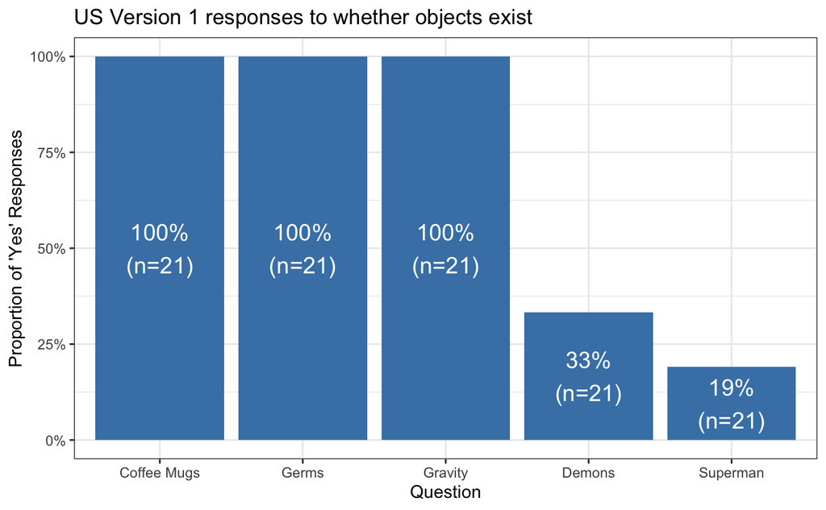

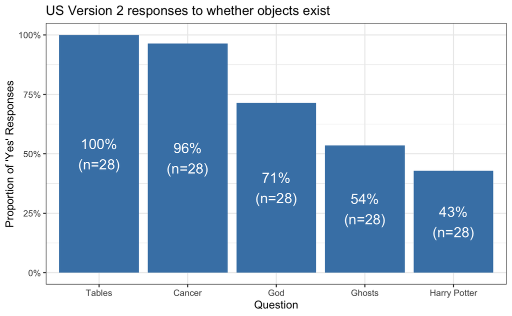

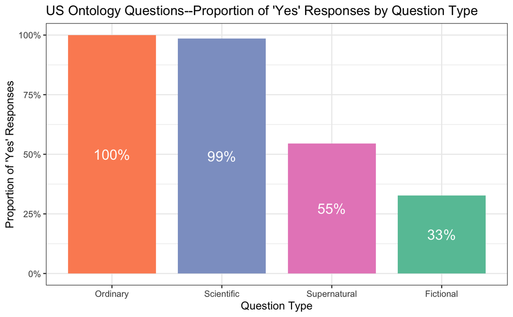

### Ghana

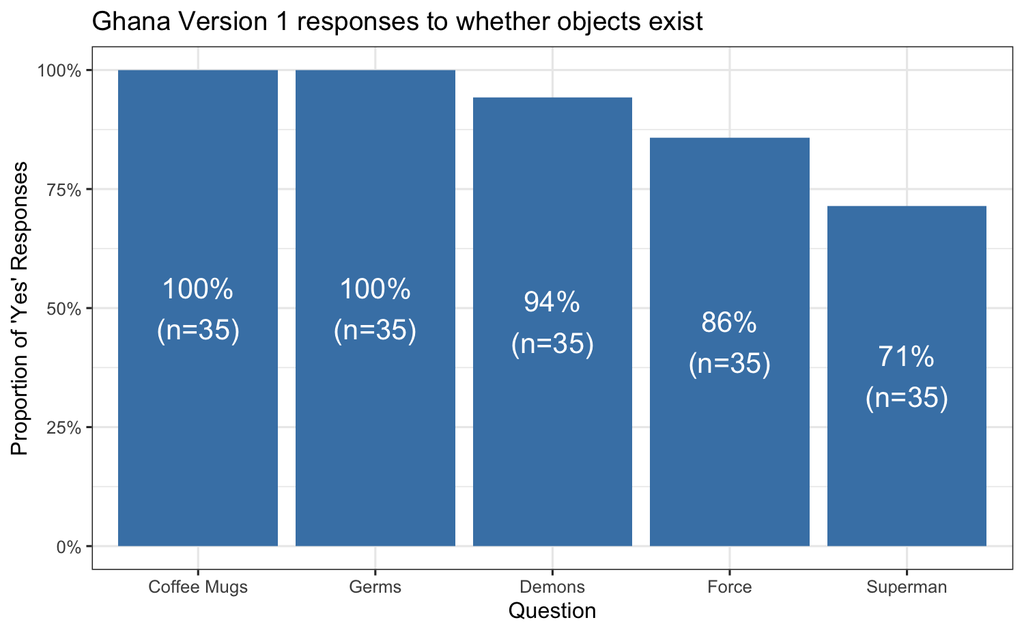

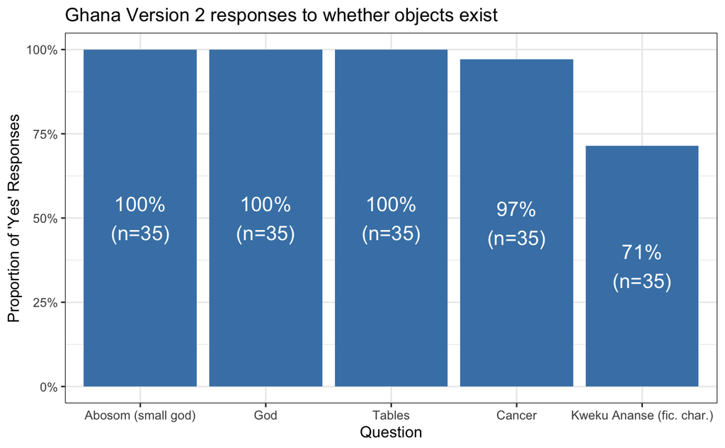

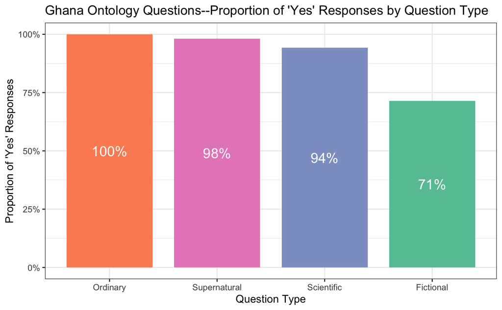

### Ecuador

[figure not shown]

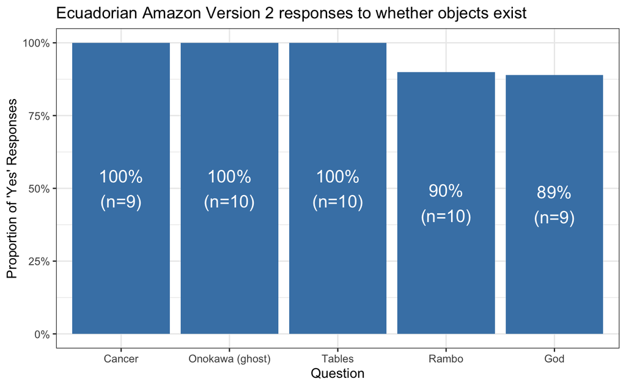

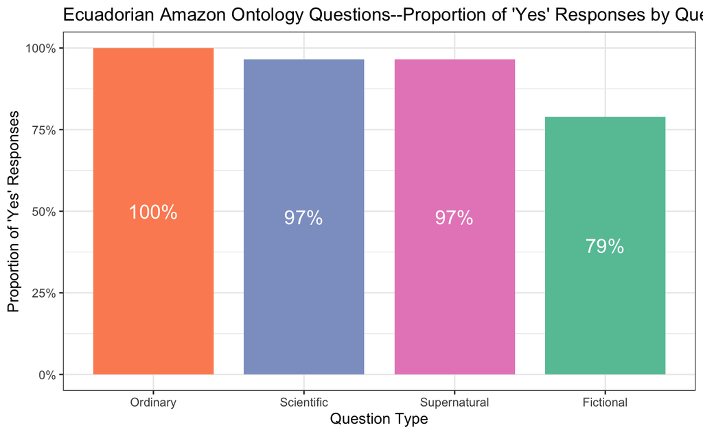

### Peru

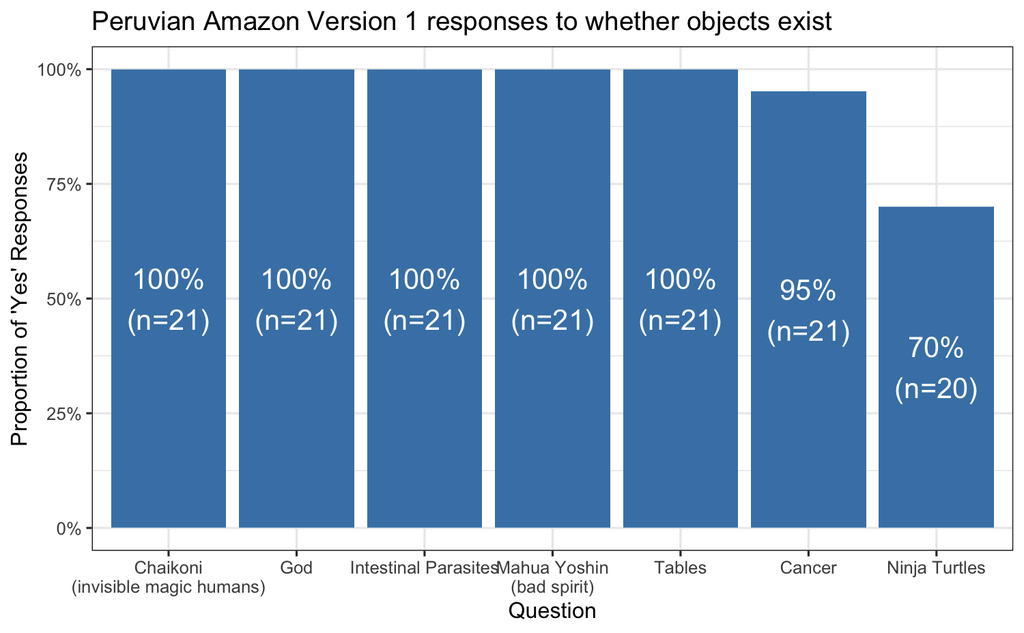

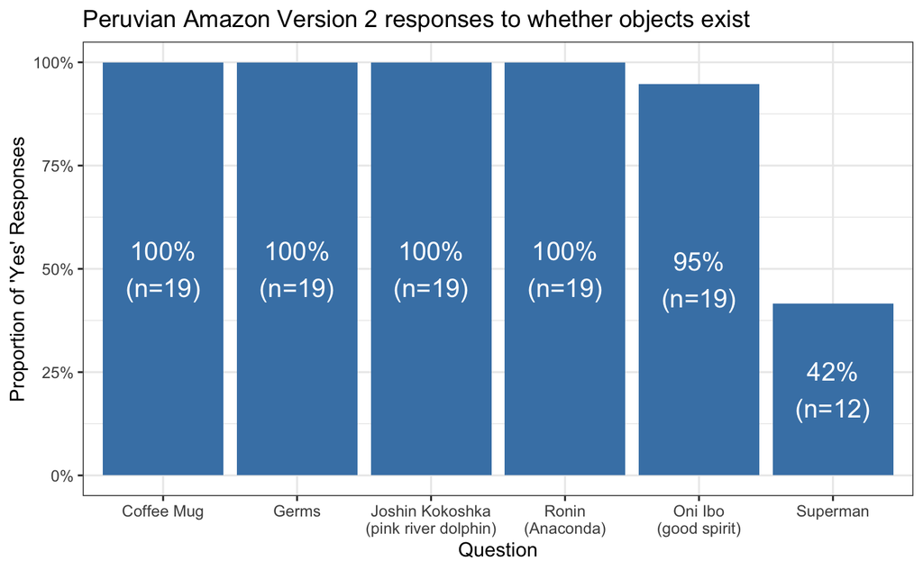

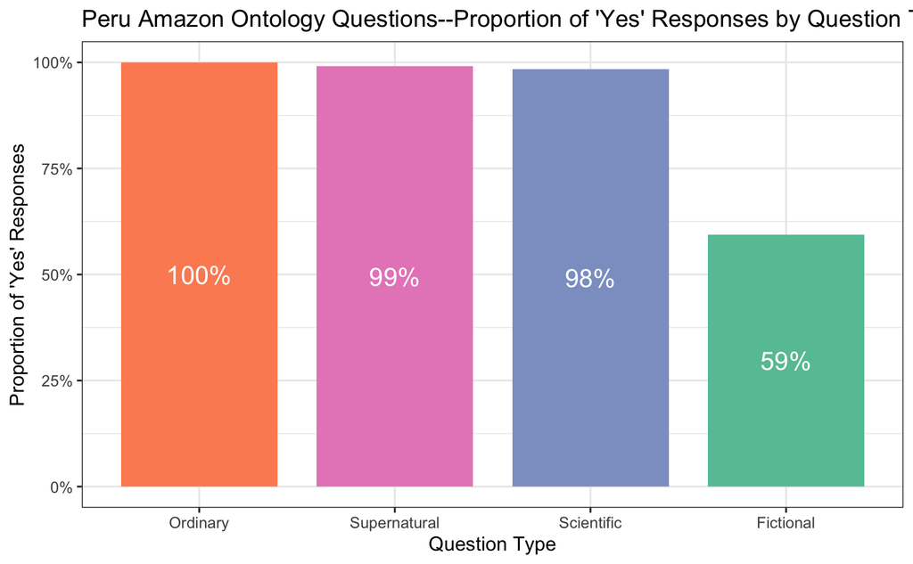

## Confidence

### US

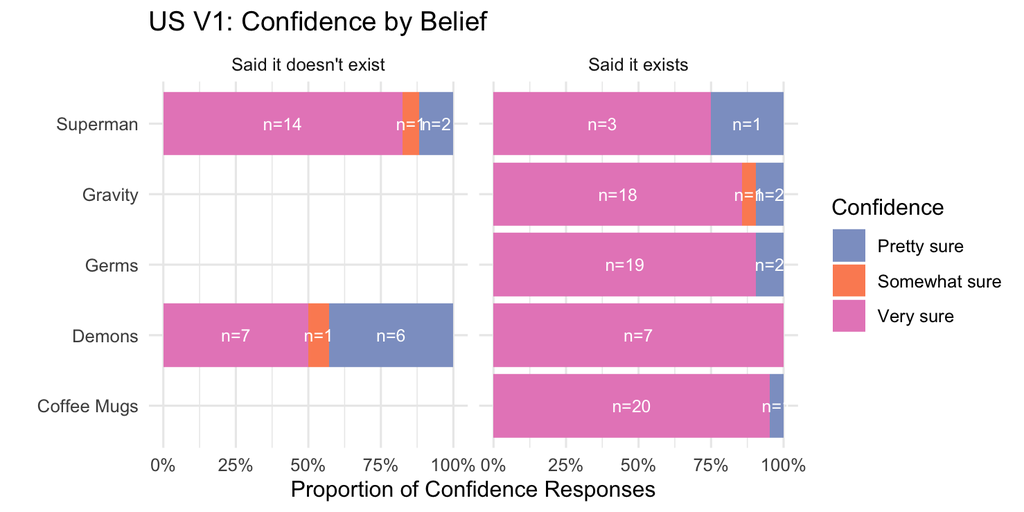

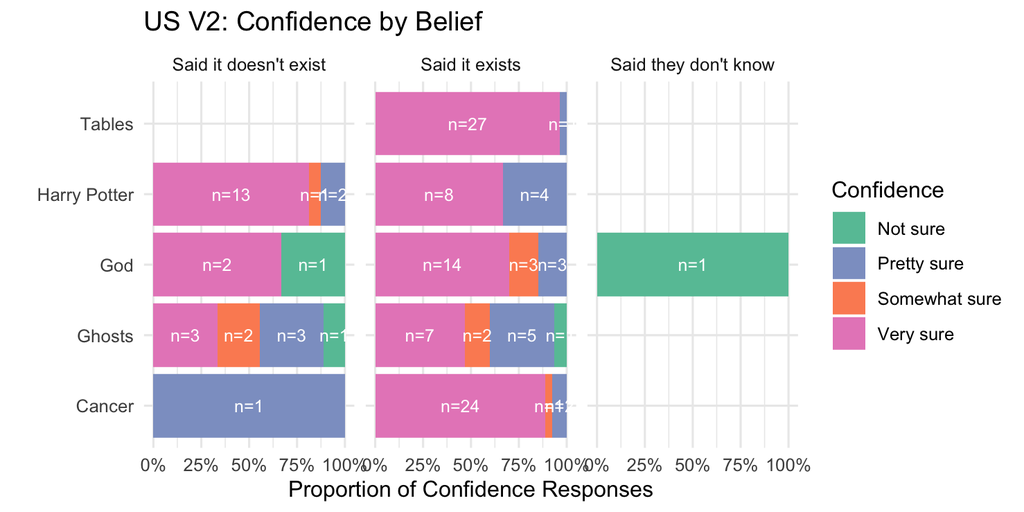

### Ghana

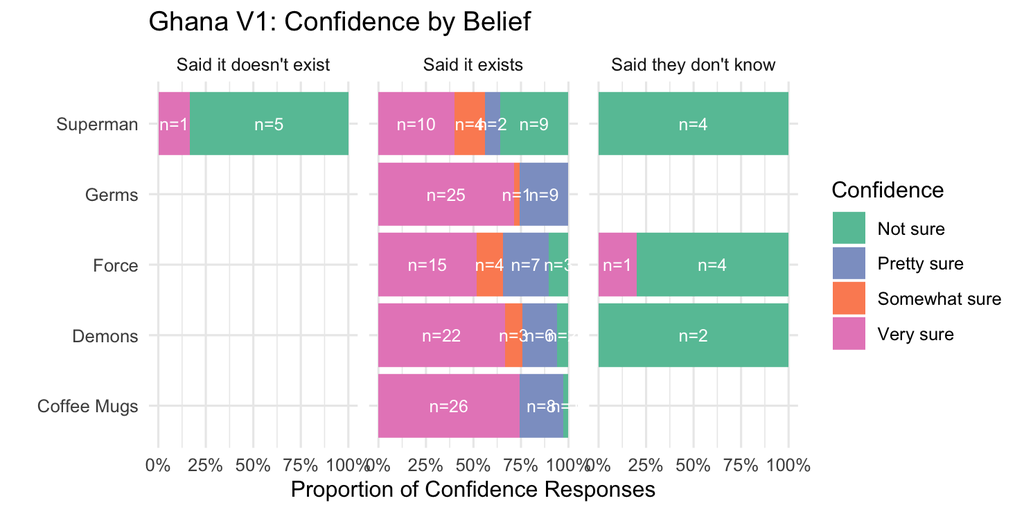

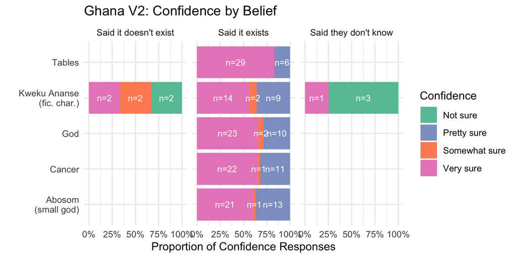

### Ecuador

[figure not shown]

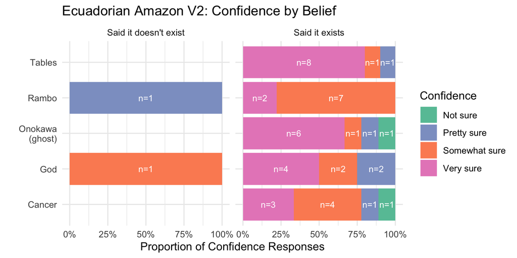

### Peru

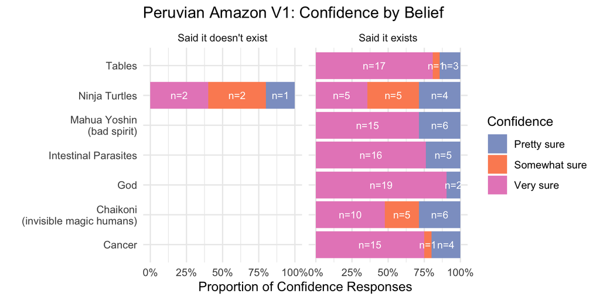

[figure not shown]

## Communication

### US

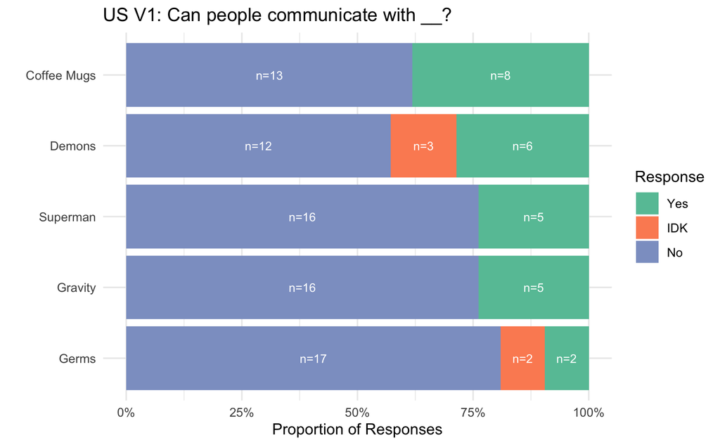

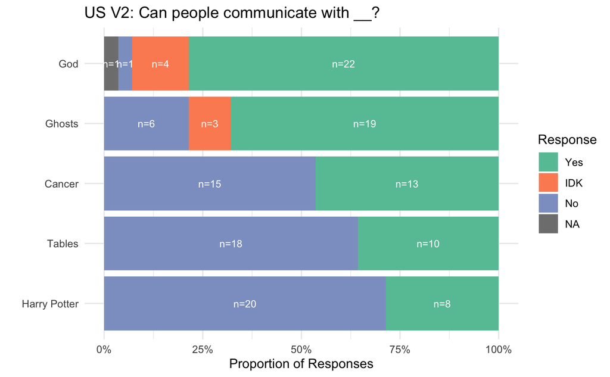

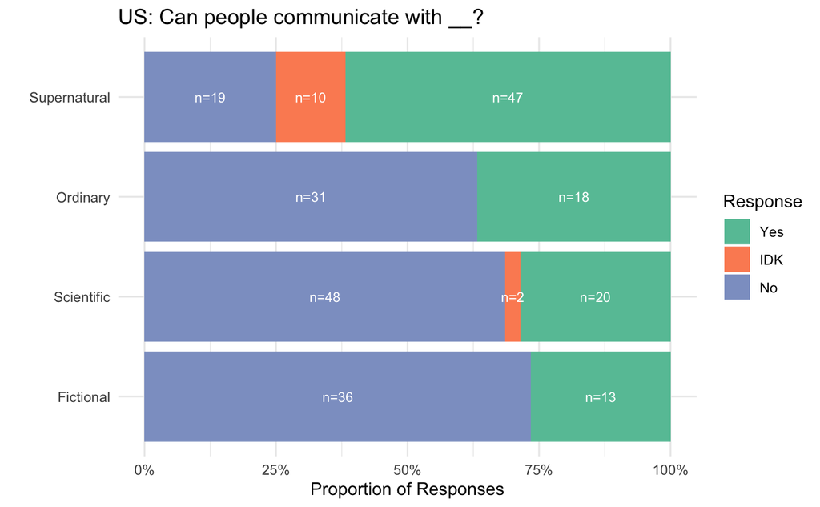

### Ghana

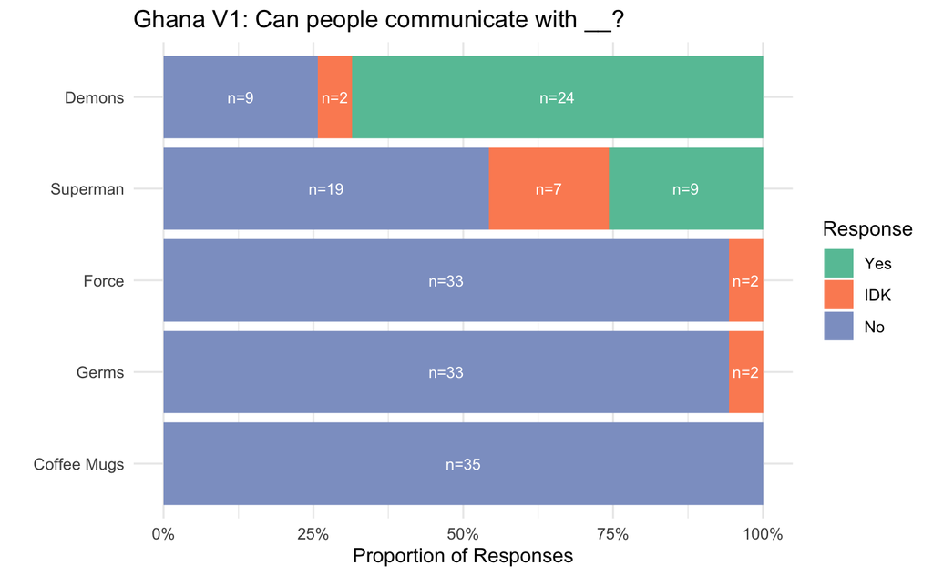

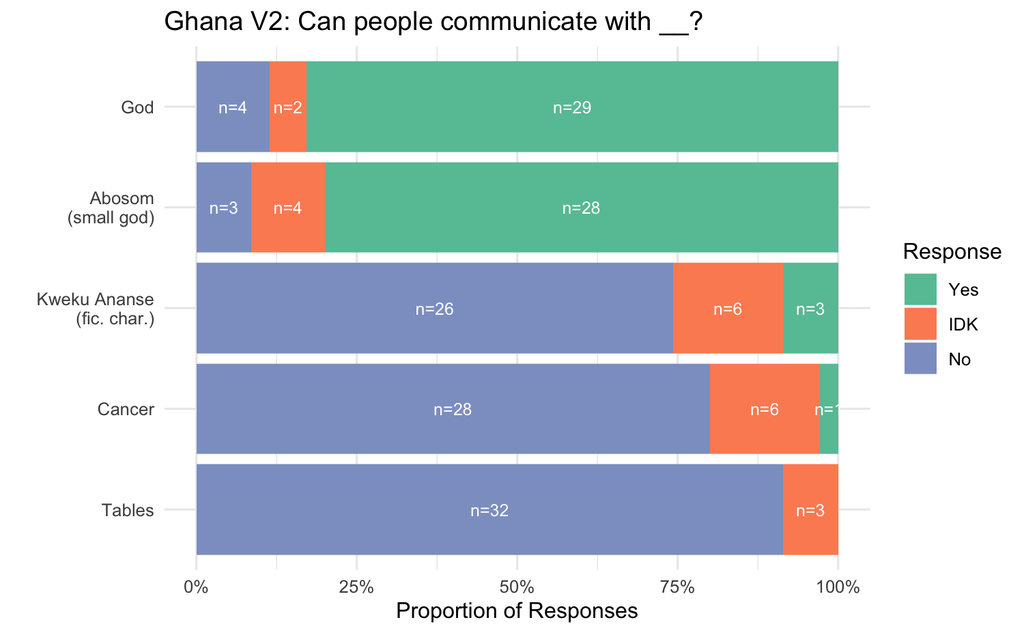

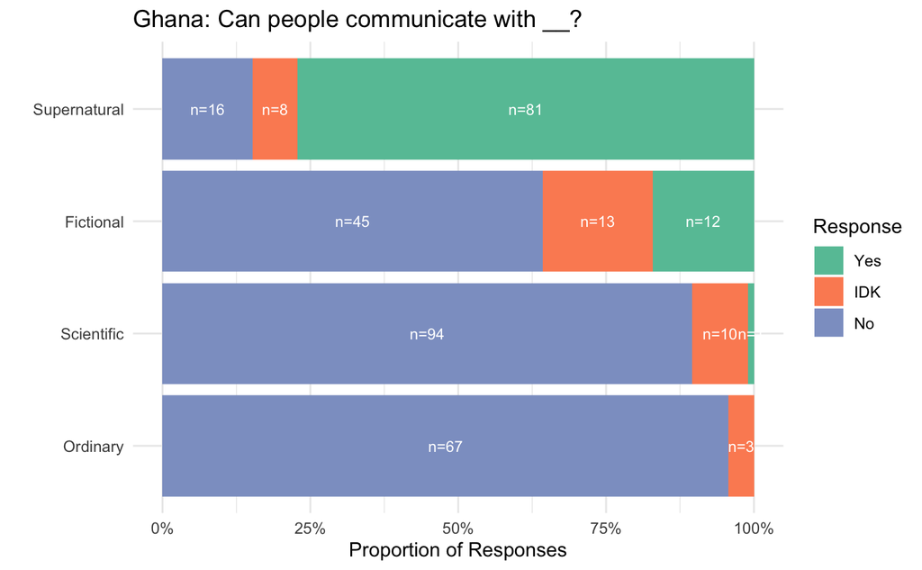